# MATH624_Final_Project_EMPLOYEE_ATTRITION_PREDICTION_HR_ANALYTICS

Luc Nguyen

2025-12-07

# BUSINESS PROBLEM:

- When employees leave a company, it can end up costing you. You have to spend money on recruiting new people, and you also lose productivity. The goal of this project is to use statistical methods to (1) identify which employees are most likely to leave the company and (2) understand the different types of employees within the workforce. These insights will help HR teams come up with the right solutions to keep employees from leaving and improve retention.
- The target variable in this project is Attrition variable.

# 0. SETUP & LIBRARIES

```r
library(tidyverse)      # Data manipulation
```

```r
library(corrplot)       # Correlation plots
library(ggplot2)        # Advanced plotting
library(factoextra)
```

# 1. LOAD DATA

```r
# Read the CSV
hr <- read.csv("HR_Employee_Attrition.csv", header=TRUE)

# Inspect dimensions
dim(hr)
```

```
## [1] 1470   35
```

```r
# Inspect structure
str(hr)
```

```
## 'data.frame':    1470 obs. of  35 variables:
##  $ Age                     : int  41 49 37 33 27 32 59 30 38 36 ...
##  $ Attrition               : chr  "Yes" "No" "Yes" "No" ...
##  $ BusinessTravel          : chr  "Travel_Rarely" "Travel_Frequently" "Travel_Rarely" "Travel_Frequently" ...
##  $ DailyRate               : int  1102 279 1373 1392 591 1005 1324 1358 216 1299 ...
##  $ Department              : chr  "Sales" "Research & Development" "Research & Development" "Research & Development" ...
##  $ DistanceFromHome        : int  1 8 2 3 2 2 3 24 23 27 ...
##  $ Education               : int  2 1 2 4 1 2 3 1 3 3 ...
##  $ EducationField          : chr  "Life Sciences" "Life Sciences" "Other" "Life Sciences" ...
##  $ EmployeeCount           : int  1 1 1 1 1 1 1 1 1 1 ...
##  $ EmployeeNumber          : int  1 2 4 5 7 8 10 11 12 13 ...
##  $ EnvironmentSatisfaction : int  2 3 4 4 1 4 3 4 4 3 ...
##  $ Gender                  : chr  "Female" "Male" "Male" "Female" ...
##  $ HourlyRate              : int  94 61 92 56 40 79 81 67 44 94 ...
##  $ JobInvolvement          : int  3 2 2 3 3 3 4 3 2 3 ...
```

[output cut: 21 more lines]

```r
# Show five first rows
head(hr)
```

```
##   Age Attrition    BusinessTravel DailyRate             Department
## 1  41       Yes     Travel_Rarely      1102                  Sales
## 2  49        No Travel_Frequently       279 Research & Development
## 3  37       Yes     Travel_Rarely      1373 Research & Development
## 4  33        No Travel_Frequently      1392 Research & Development
## 5  27        No     Travel_Rarely       591 Research & Development
## 6  32        No Travel_Frequently      1005 Research & Development
##   DistanceFromHome Education EducationField EmployeeCount EmployeeNumber
## 1                1         2  Life Sciences             1              1
## 2                8         1  Life Sciences             1              2
## 3                2         2          Other             1              4
## 4                3         4  Life Sciences             1              5
## 5                2         1        Medical             1              7
## 6                2         2  Life Sciences             1              8
##   EnvironmentSatisfaction Gender HourlyRate JobInvolvement JobLevel
```

[output cut: 41 more lines]

```r
# Convert some variables to factor
hr <- hr %>%
  mutate(
    Attrition = as.factor(Attrition),
    BusinessTravel = as.factor(BusinessTravel),
    Department = as.factor(Department),
    EducationField = as.factor(EducationField),
    Gender = as.factor(Gender),
    JobRole = as.factor(JobRole),
    MaritalStatus = as.factor(MaritalStatus),
    OverTime = as.factor(OverTime)
)
```

```r
# Remove irrelevant columns
hr_clean <- hr[, !(names(hr) %in% c("EmployeeCount","EmployeeNumber", "Over18", "StandardHours"))]

str(hr_clean)
```

```
## 'data.frame':    1470 obs. of  31 variables:
##  $ Age                     : int  41 49 37 33 27 32 59 30 38 36 ...
##  $ Attrition               : Factor w/ 2 levels "No","Yes": 2 1 2 1 1 1 1 1 1 1 ...
##  $ BusinessTravel          : Factor w/ 3 levels "Non-Travel","Travel_Frequently",..: 3 2 3 2 3 2 3 3 2 3 ...
##  $ DailyRate               : int  1102 279 1373 1392 591 1005 1324 1358 216 1299 ...
##  $ Department              : Factor w/ 3 levels "Human Resources",..: 3 2 2 2 2 2 2 2 2 2 ...
##  $ DistanceFromHome        : int  1 8 2 3 2 2 3 24 23 27 ...
##  $ Education               : int  2 1 2 4 1 2 3 1 3 3 ...
##  $ EducationField          : Factor w/ 6 levels "Human Resources",..: 2 2 5 2 4 2 4 2 2 4 ...
##  $ EnvironmentSatisfaction : int  2 3 4 4 1 4 3 4 4 3 ...
##  $ Gender                  : Factor w/ 2 levels "Female","Male": 1 2 2 1 2 2 1 2 2 2 ...
##  $ HourlyRate              : int  94 61 92 56 40 79 81 67 44 94 ...
##  $ JobInvolvement          : int  3 2 2 3 3 3 4 3 2 3 ...
##  $ JobLevel                : int  2 2 1 1 1 1 1 1 3 2 ...
##  $ JobRole                 : Factor w/ 9 levels "Healthcare Representative",..: 8 7 3 7 3 3 3 3 5 1 ...
```

[output cut: 17 more lines]

```r
names(hr_clean)
```

```
##  [1] "Age"                      "Attrition"
##  [3] "BusinessTravel"           "DailyRate"
##  [5] "Department"               "DistanceFromHome"
##  [7] "Education"                "EducationField"
##  [9] "EnvironmentSatisfaction"  "Gender"
## [11] "HourlyRate"               "JobInvolvement"
## [13] "JobLevel"                 "JobRole"
## [15] "JobSatisfaction"          "MaritalStatus"
## [17] "MonthlyIncome"            "MonthlyRate"
## [19] "NumCompaniesWorked"       "OverTime"
## [21] "PercentSalaryHike"        "PerformanceRating"
## [23] "RelationshipSatisfaction" "StockOptionLevel"
## [25] "TotalWorkingYears"        "TrainingTimesLastYear"
## [27] "WorkLifeBalance"          "YearsAtCompany"
## [29] "YearsInCurrentRole"       "YearsSinceLastPromotion"
## [31] "YearsWithCurrManager"
```

# 2. EXPLORATORY DATA ANALYSIS (EDA)

## 2.1 Check class imbalance

```r
# Frequency table
attrition_table <- table(hr_clean$Attrition)
print(attrition_table)
```

```
##
##   No  Yes
## 1233  237
```

```r
# Proportions
attrition_prop <- prop.table(attrition_table)
print(round(attrition_prop * 100, 2))
```

```
##
##    No   Yes
## 83.88 16.12
```

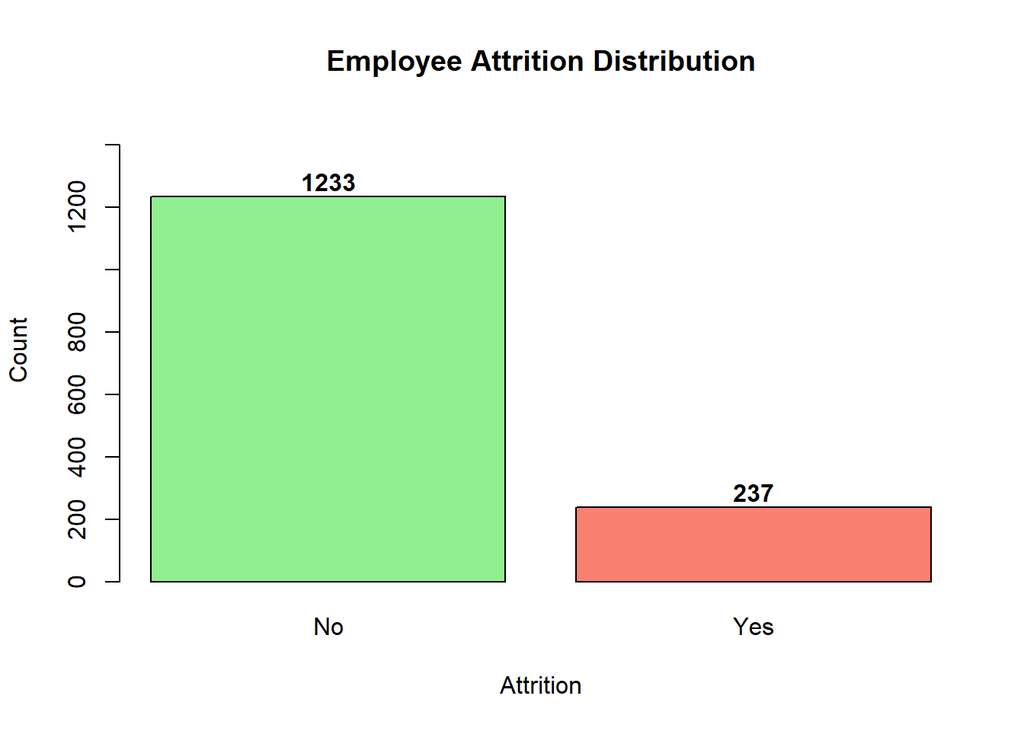

```r
# Visualization
par(mfrow=c(1,1))
barplot(attrition_table, main="Employee Attrition Distribution",
          xlab="Attrition", ylab="Count",
          col=c("lightgreen", "salmon"),
          border="black", ylim=c(0, max(attrition_table) * 1.2))

# Add counts on bars
text(x = c(0.7, 1.9), y = attrition_table + 50,
     labels = attrition_table, font = 2)
```

```r
cat("\nFinding: ", round(attrition_prop[2] * 100, 1), "% of employees left the company\n")
```

```
##
## Finding:  16.1 % of employees left the company
```

- Only 16.1% of employees left (class imbalance)
- This means our models may be biased toward “No” predictions
- We should pay attention to Sensitivity (catching the “Yes” cases)

## 2.2 Missing values

```r
missing_counts <- colSums(is.na(hr_clean))
total_missing <- sum(is.na(hr_clean))

cat("Total missing: ", total_missing, "\n")
```

```
## Total missing:  0
```

```r
if(total_missing > 0){
  cat("\nColumns with missing values:\n")
  print(missing_counts[missing_counts > 0])
} else {
  cat("No missing values detected! Clean dataset.\n")
}
```

```
## No missing values detected! Clean dataset.
```

## 2.3 Summary statistics

```r
summary(hr_clean)
```

```
##       Age        Attrition            BusinessTravel   DailyRate
##  Min.   :18.00   No :1233   Non-Travel       : 150   Min.   : 102.0
##  1st Qu.:30.00   Yes: 237   Travel_Frequently: 277   1st Qu.: 465.0
##  Median :36.00              Travel_Rarely    :1043   Median : 802.0
##  Mean   :36.92                                       Mean   : 802.5
##  3rd Qu.:43.00                                       3rd Qu.:1157.0
##  Max.   :60.00                                       Max.   :1499.0
##
##                   Department  DistanceFromHome   Education
##  Human Resources       : 63   Min.   : 1.000   Min.   :1.000
##  Research & Development:961   1st Qu.: 2.000   1st Qu.:2.000
##  Sales                 :446   Median : 7.000   Median :3.000
##                               Mean   : 9.193   Mean   :2.913
##                               3rd Qu.:14.000   3rd Qu.:4.000
##                               Max.   :29.000   Max.   :5.000
##
##           EducationField EnvironmentSatisfaction    Gender      HourlyRate
##  Human Resources : 27    Min.   :1.000           Female:588   Min.   : 30.00
##  Life Sciences   :606    1st Qu.:2.000           Male  :882   1st Qu.: 48.00
##  Marketing       :159    Median :3.000                        Median : 66.00
##  Medical         :464    Mean   :2.722                        Mean   : 65.89
##  Other           : 82    3rd Qu.:4.000                        3rd Qu.: 83.75
##  Technical Degree:132    Max.   :4.000                        Max.   :100.00
##
##  JobInvolvement    JobLevel                          JobRole    JobSatisfaction
##  Min.   :1.00   Min.   :1.000   Sales Executive          :326   Min.   :1.000
##  1st Qu.:2.00   1st Qu.:1.000   Research Scientist       :292   1st Qu.:2.000
##  Median :3.00   Median :2.000   Laboratory Technician    :259   Median :3.000
##  Mean   :2.73   Mean   :2.064   Manufacturing Director   :145   Mean   :2.729
##  3rd Qu.:3.00   3rd Qu.:3.000   Healthcare Representative:131   3rd Qu.:4.000
##  Max.   :4.00   Max.   :5.000   Manager                  :102   Max.   :4.000
##                                 (Other)                  :215
##   MaritalStatus MonthlyIncome    MonthlyRate    NumCompaniesWorked OverTime
##  Divorced:327   Min.   : 1009   Min.   : 2094   Min.   :0.000      No :1054
##  Married :673   1st Qu.: 2911   1st Qu.: 8047   1st Qu.:1.000      Yes: 416
##  Single  :470   Median : 4919   Median :14236   Median :2.000
##                 Mean   : 6503   Mean   :14313   Mean   :2.693
##                 3rd Qu.: 8379   3rd Qu.:20462   3rd Qu.:4.000
##                 Max.   :19999   Max.   :26999   Max.   :9.000
##
```

[output cut: 9 more lines]

```
##  Min.   : 0.00     Min.   :0.000         Min.   :1.000   Min.   : 0.000
##  1st Qu.: 6.00     1st Qu.:2.000         1st Qu.:2.000   1st Qu.: 3.000
##  Median :10.00     Median :3.000         Median :3.000   Median : 5.000
##  Mean   :11.28     Mean   :2.799         Mean   :2.761   Mean   : 7.008
##  3rd Qu.:15.00     3rd Qu.:3.000         3rd Qu.:3.000   3rd Qu.: 9.000
##  Max.   :40.00     Max.   :6.000         Max.   :4.000   Max.   :40.000
##
##  YearsInCurrentRole YearsSinceLastPromotion YearsWithCurrManager
##  Min.   : 0.000     Min.   : 0.000          Min.   : 0.000
##  1st Qu.: 2.000     1st Qu.: 0.000          1st Qu.: 2.000
##  Median : 3.000     Median : 1.000          Median : 3.000
##  Mean   : 4.229     Mean   : 2.188          Mean   : 4.123
##  3rd Qu.: 7.000     3rd Qu.: 3.000          3rd Qu.: 7.000
##  Max.   :18.000     Max.   :15.000          Max.   :17.000
##
```

## 2.4 Histograms for important numeric values

```r
numeric_cols <- names(hr_clean)[sapply(hr_clean, is.numeric)]
features_numeric_cols <- c("Age", "DistanceFromHome", "YearsAtCompany", "MonthlyIncome", "JobSatisfaction", "WorkLifeBalance")
features_numeric_cols
```

```
## [1] "Age"              "DistanceFromHome" "YearsAtCompany"   "MonthlyIncome"
## [5] "JobSatisfaction"  "WorkLifeBalance"
```

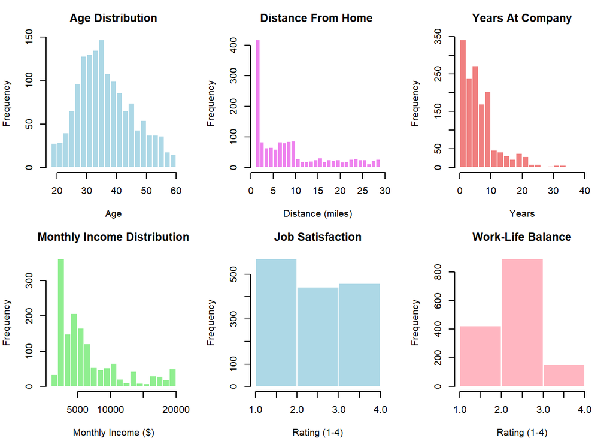

```r
par(mfrow=c(2, 3), mar = c(4, 4, 3, 2))

# Age
hist(hr_clean$Age, main="Age Distribution", xlab="Age", col="lightblue", border = "white", breaks = 20)

# DistanceFromHome
hist(hr_clean$DistanceFromHome, main="Distance From Home ", xlab="Distance (miles)", col="violet", border = "white", breaks = 20)

# YearsAtCompany
hist(hr_clean$YearsAtCompany, main="Years At Company", xlab="Years", col="lightcoral", border = "white", breaks = 20)

# MonthlyIncome
hist(hr_clean$MonthlyIncome, main="Monthly Income Distribution", xlab="Monthly Income ($)", col="lightgreen", border="white", breaks=20)

# JobSatisfaction
hist(hr_clean$JobSatisfaction, main="Job Satisfaction", xlab="Rating (1-4)", col="lightblue", border="white", breaks=4)

# WorkLifeBalance
hist(hr_clean$WorkLifeBalance, main="Work-Life Balance", xlab="Rating (1-4)", col="lightpink", border="white", breaks=4)
```

```r
# Reset plotting area
par(mfrow=c(1,1))
```

- Age:
  - bell-shaped distribution.
  - most employees are 30-45.
- DistanceFromHome:
  - right-skwewed -> most live close to work
  - a few live 20-30 miles away.
- YearAtCompany:
  - many new employees (0-10 years).
  - very few long-tenure employees (20-40 years).
- MonthlyIncome:
  - heavily right-skewed –> potential log-transform later.
  - most employees earn under $8k.
- JobSatisfaction:
  - fairly evenly distributed (but few 1’s).
- Work-Life Balace:
  - most employees rate 2-3 –> it’s average level.
  - a few employees rate more than 3.

## 2.5 Boxplots vs Attrition

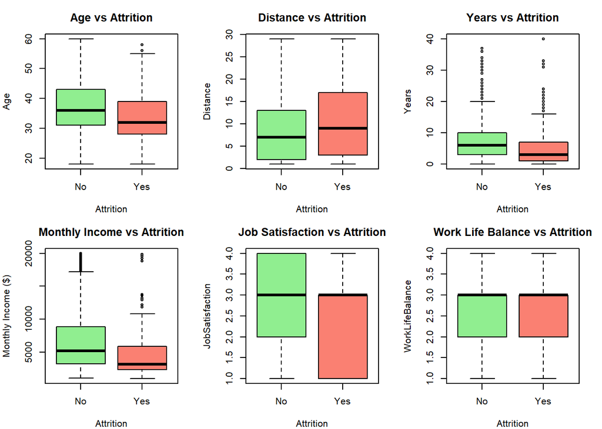

```r
par(mfrow=c(2, 3), mar = c(4, 4, 3, 2))

# Age vs Attrition
boxplot(Age ~ Attrition, data=hr_clean, main="Age vs Attrition", xlab="Attrition", ylab="Age", col=c("lightgreen", "salmon"), border="black")

# Distance vs Attrition
boxplot(DistanceFromHome ~ Attrition, data=hr_clean, main="Distance vs Attrition", xlab="Attrition", ylab="Distance", col=c("lightgreen", "salmon"), border="black")

# YearsAtCompany vs Attrition
boxplot(YearsAtCompany ~ Attrition, data=hr_clean, main="Years vs Attrition", xlab="Attrition", ylab="Years", col=c("lightgreen", "salmon"), border="black")

# MonthlyIncome vs Attrition
boxplot(MonthlyIncome ~ Attrition, data=hr_clean, main="Monthly Income vs Attrition", xlab="Attrition", ylab="Monthly Income ($)", col=c("lightgreen", "salmon"), border="black")

# JobSatisfaction vs Attrition
boxplot(JobSatisfaction ~ Attrition, data=hr_clean, main="Job Satisfaction vs Attrition", xlab="Attrition", ylab="JobSatisfaction", col=c("lightgreen", "salmon"), border="black")

# WorkLifeBalance
boxplot(WorkLifeBalance ~ Attrition, data=hr_clean, main="Work Life Balance vs Attrition", xlab="Attrition", ylab="WorkLifeBalance", col=c("lightgreen", "salmon"), border="black")
```

```r
# Reset plotting area
par(mfrow=c(1,1))
```

## 2.6 Correlation matrix (numeric only)

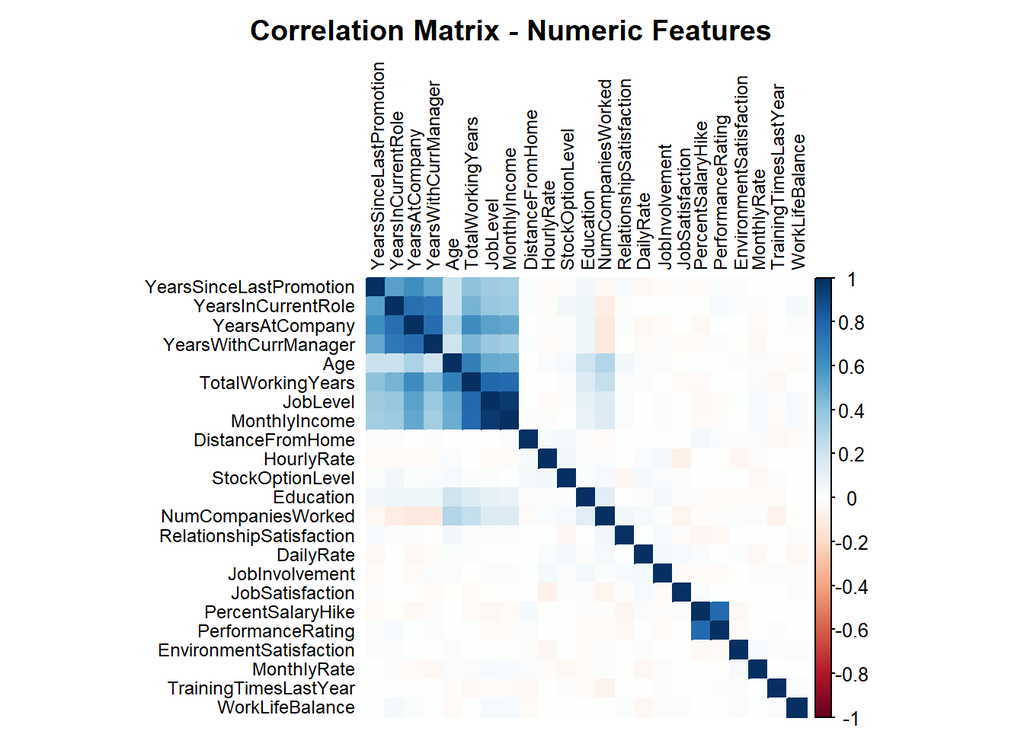

```r
# Calculate correlation
cor_matrix <- cor(hr_clean[, numeric_cols], use = "complete.obs")

# Plot correlation matrix
corrplot(cor_matrix,
         method = "color",
         type = "full",
         tl.cex = 0.75,
         tl.col = "black",
         title = "Correlation Matrix - Numeric Features",
         order="hclust",
         mar = c(0, 0, 2, 0))
```

```r
cat("\n==== EDA ANALYSIS SUMMARY ===\n")
```

```
##
## ==== EDA ANALYSIS SUMMARY ===
```

```r
cat("Dataset size: ", nrow(hr_clean), "employees ", ncol(hr_clean), "features\n")
```

```
## Dataset size:  1470 employees  31 features
```

```r
cat("Attrition rate: ", round(attrition_prop[2] * 100, 2), "%\n")
```

```
## Attrition rate:  16.12 %
```

```r
cat("Class imbalance: 1233 No vs 237 Yes \n")
```

```
## Class imbalance: 1233 No vs 237 Yes
```

```r
cat("No missing values\n")
```

```
## No missing values
```

```r
cat("Strong correlation: Tenure-Role, Age-Experience, Income-JobLevel\n")
```

```
## Strong correlation: Tenure-Role, Age-Experience, Income-JobLevel
```

```r
cat("Key predictors identified: Age, Income, Tenure, JobSatisfaction\n")
```

```
## Key predictors identified: Age, Income, Tenure, JobSatisfaction
```

# 3. UNSUPERVISED LEARNING

- Definition: finding patterns in data without a target variable (no “labels” to predict)
- In our project:

  ```
  * don't use Attrition (yet!).
  * look at employees features only.
  * discover natural groupings.
  * find hidden patterns.
  ```

## 3.1 PRINCIPAL COMPONENT ANALYSIS (PCA)

```r
# Select only numeric columns
numeric_cols_data <- hr_clean[, sapply(hr_clean, is.numeric)]
num_numeric_cols <- ncol(numeric_cols_data)
cat("\nNumber of numeric columns is: ", num_numeric_cols, "\n")
```

```
##
## Number of numeric columns is:  23
```

```r
# Standardize with scale()
scaled_data <- scale(numeric_cols_data, center=TRUE, scale=TRUE)

# Run PCA
hr_pca <- prcomp(scaled_data, center = FALSE, scale. = FALSE)

# Print summary
print(summary(hr_pca))
```

```
## Importance of components:
##                           PC1     PC2     PC3     PC4     PC5     PC6     PC7
## Standard deviation     2.1577 1.35502 1.32483 1.09177 1.04223 1.02871 1.02546
## Proportion of Variance 0.2024 0.07983 0.07631 0.05182 0.04723 0.04601 0.04572
## Cumulative Proportion  0.2024 0.28225 0.35856 0.41039 0.45762 0.50363 0.54935
##                            PC8     PC9    PC10    PC11    PC12    PC13    PC14
## Standard deviation     1.01899 1.01063 0.99532 0.98253 0.97305 0.95061 0.94978
## Proportion of Variance 0.04514 0.04441 0.04307 0.04197 0.04117 0.03929 0.03922
## Cumulative Proportion  0.59449 0.63890 0.68197 0.72394 0.76511 0.80440 0.84362
##                           PC15    PC16    PC17   PC18    PC19    PC20    PC21
## Standard deviation     0.93769 0.86826 0.73584 0.7226 0.52903 0.47548 0.45156
## Proportion of Variance 0.03823 0.03278 0.02354 0.0227 0.01217 0.00983 0.00887
## Cumulative Proportion  0.88185 0.91463 0.93817 0.9609 0.97304 0.98287 0.99173
##                           PC22   PC23
## Standard deviation     0.37649 0.2200
## Proportion of Variance 0.00616 0.0021
## Cumulative Proportion  0.99790 1.0000
```

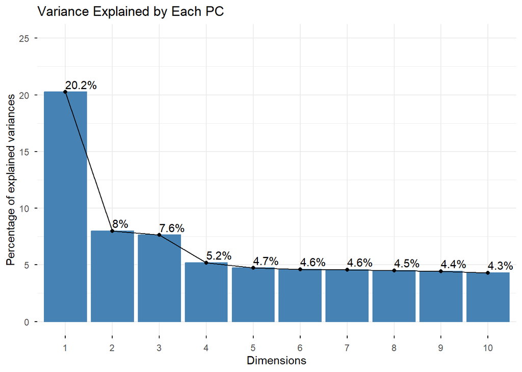

```r
# Scree plot (how many PCs to keep?)
fviz_eig(hr_pca, addlabels = TRUE, ylim = c(0, 25), main = "Variance Explained by Each PC")
```

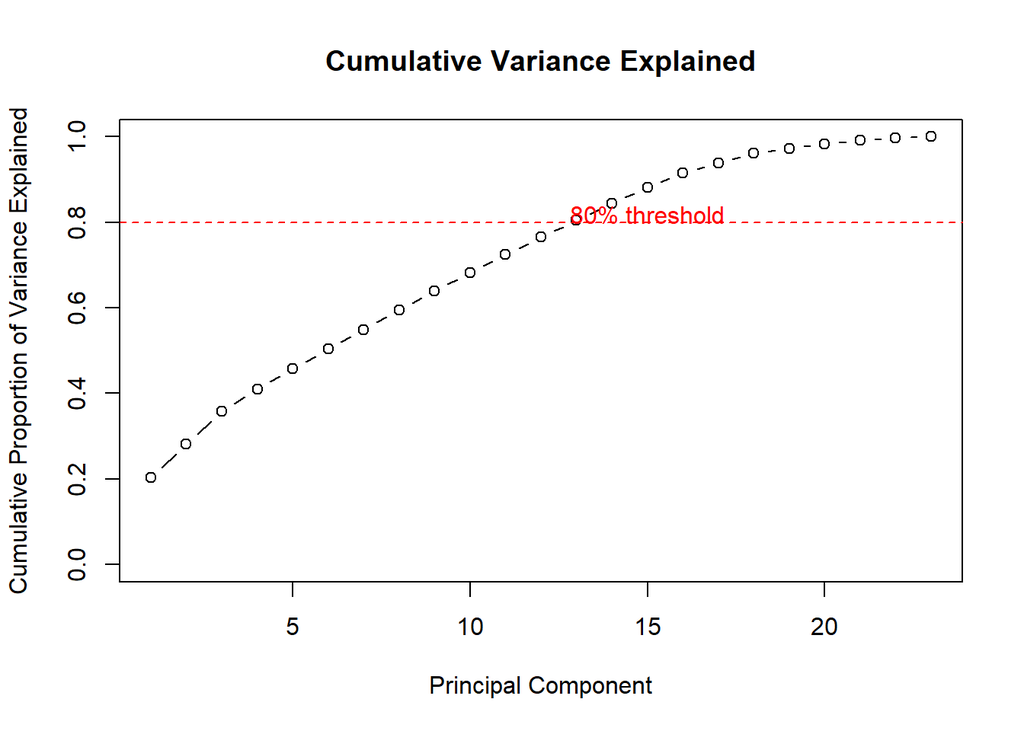

```r
# Percent of variance explained (PVE)
hr_pve <- hr_pca$sdev^2 / sum(hr_pca$sdev^2)
hr_cummulative_pve <- cumsum(hr_pve)

plot(hr_cummulative_pve, type = "b",
     xlab = "Principal Component",
     ylab = "Cumulative Proportion of Variance Explained",
     main = "Cumulative Variance Explained", ylim = c(0, 1))
     abline(h = 0.8, col = "red", lty = 2)  # 80% threshold
     text(15, 0.82, "80% threshold", col = "red")
```

```
## Ignoring unknown labels:
## • linetype : "Attrition"
```

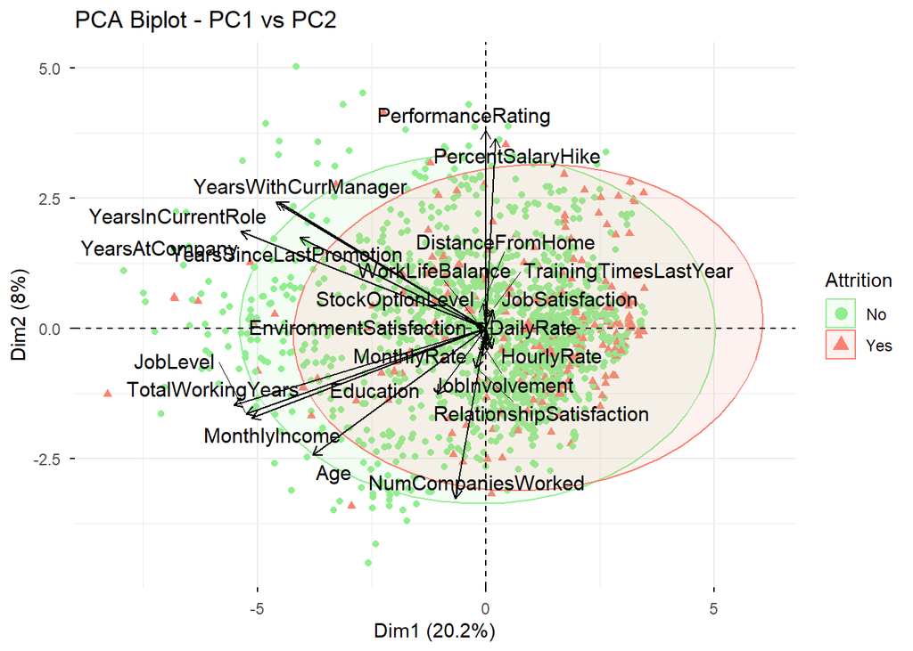

```r
# Biplot (employees plotted in PC1 vs PC2 space)
fviz_pca_biplot(hr_pca,
                geom.ind = "point",
                col.ind = hr_clean$Attrition,
                palette = c("lightgreen", "salmon"),
                addEllipses = TRUE,
                col.var = "black",
                repel = TRUE,
                legend.title = "Attrition",
                title = "PCA Biplot - PC1 vs PC2")
```

```r
cat("\n=============== PC1 LOADING =============== \n")
```

```
##
## =============== PC1 LOADING ===============
```

```r
hr_pc1 <- sort(abs(hr_pca$rotation[, 1]), decreasing = TRUE)[1:10]
print(hr_pca$rotation[names(hr_pc1), 1])
```

```
##       TotalWorkingYears          YearsAtCompany                JobLevel
##             -0.40346528             -0.39151588             -0.38282604
##           MonthlyIncome      YearsInCurrentRole    YearsWithCurrManager
##             -0.37474117             -0.33594145             -0.33039531
## YearsSinceLastPromotion                     Age               Education
##             -0.29741882             -0.27701996             -0.07792794
##      NumCompaniesWorked
##             -0.04849526
```

```r
cat("\n=============== PC2 LOADING =============== \n")
```

```
##
## =============== PC2 LOADING ===============
```

```r
hr_pc2 <- sort(abs(hr_pca$rotation[, 2]), decreasing = TRUE)[1:10]
print(hr_pca$rotation[names(hr_pc2), 2])
```

```
##       PerformanceRating       PercentSalaryHike      NumCompaniesWorked
##               0.4428432               0.4241301              -0.3793835
##                     Age    YearsWithCurrManager      YearsInCurrentRole
##              -0.2833933               0.2821884               0.2821508
##          YearsAtCompany YearsSinceLastPromotion           MonthlyIncome
##               0.2169211               0.2036922              -0.2003324
##                JobLevel
##              -0.1912103
```

```r
cat("\n=============== PC3 LOADING =============== \n")
```

```
##
## =============== PC3 LOADING ===============
```

```r
hr_pc3 <- sort(abs(hr_pca$rotation[, 3]), decreasing = TRUE)[1:10]
print(hr_pca$rotation[names(hr_pc3), 3])
```

```
##       PercentSalaryHike       PerformanceRating      NumCompaniesWorked
##               0.5596398               0.5433359               0.3043270
##                     Age    YearsWithCurrManager      YearsInCurrentRole
##               0.2546016              -0.2131292              -0.1975523
##          YearsAtCompany YearsSinceLastPromotion       TotalWorkingYears
##              -0.1817945              -0.1621022               0.1521116
##           MonthlyIncome
##               0.1516890
```

```r
cat("\n╔══════════════════════════════════════════════════════════════╗\n")
```

```
##
## ╔══════════════════════════════════════════════════════════════╗
```

```r
cat("║                 PCA ANALYSIS SUMMARY                  ║\n")
```

```
## ║                 PCA ANALYSIS SUMMARY                  ║
```

```r
cat("╚══════════════════════════════════════════════════════════════╝\n\n")
```

```
## ╚══════════════════════════════════════════════════════════════╝
```

```r
cat("1. DIMENSIONALITY REDUCTION:\n")
```

```
## 1. DIMENSIONALITY REDUCTION:
```

```r
cat("   • Original features: 23 numeric variables\n")
```

```
##    • Original features: 23 numeric variables
```

```r
cat("   • Optimal PCs: 10-13 components\n")
```

```
##    • Optimal PCs: 10-13 components
```

```r
cat("   • First 10 PCs explain: 68.2% of total variance\n")
```

```
##    • First 10 PCs explain: 68.2% of total variance
```

```r
cat("   • First 13 PCs explain: 80.4% of total variance (✓ 80% threshold)\n")
```

```
##    • First 13 PCs explain: 80.4% of total variance (✓ 80% threshold)
```

```r
cat("   • Dimension reduction achieved: 23 → 13 (43% reduction)\n")
```

```
##    • Dimension reduction achieved: 23 → 13 (43% reduction)
```

```r
cat("   • Information retained: 80.4%\n\n")
```

```
##    • Information retained: 80.4%
```

```r
cat("2. PRINCIPAL COMPONENT INTERPRETATIONS:\n\n")
```

```
## 2. PRINCIPAL COMPONENT INTERPRETATIONS:
```

```r
cat("   ━━━━━━━━━━━━━━━━━━━━━━━━━━━━━━━━━━━━━━━━━━━━━━━━━━━━━━━\n")
```

```
##    ━━━━━━━━━━━━━━━━━━━━━━━━━━━━━━━━━━━━━━━━━━━━━━━━━━━━━━━
```

```r
cat("   PC1 (20.2% variance) = 'CAREER SENIORITY & TENURE'\n")
```

```
##    PC1 (20.2% variance) = 'CAREER SENIORITY & TENURE'
```

```r
cat("   ━━━━━━━━━━━━━━━━━━━━━━━━━━━━━━━━━━━━━━━━━━━━━━━━━━━━━━━\n")
```

```
##    ━━━━━━━━━━━━━━━━━━━━━━━━━━━━━━━━━━━━━━━━━━━━━━━━━━━━━━━
```

```r
cat("   Top loadings (all negative):\n")
```

```
##    Top loadings (all negative):
```

```r
cat("     • TotalWorkingYears      : -0.403\n")
```

```
##      • TotalWorkingYears      : -0.403
```

```r
cat("     • YearsAtCompany         : -0.392\n")
```

```
##      • YearsAtCompany         : -0.392
```

```r
cat("     • JobLevel               : -0.383\n")
```

```
##      • JobLevel               : -0.383
```

```r
cat("     • MonthlyIncome          : -0.375\n")
```

```
##      • MonthlyIncome          : -0.375
```

```r
cat("     • YearsInCurrentRole     : -0.336\n")
```

```
##      • YearsInCurrentRole     : -0.336
```

```r
cat("     • YearsWithCurrManager   : -0.330\n")
```

```
##      • YearsWithCurrManager   : -0.330
```

```r
cat("     • YearsSinceLastPromotion: -0.297\n")
```

```
##      • YearsSinceLastPromotion: -0.297
```

```r
cat("     • Age                    : -0.277\n\n")
```

```
##      • Age                    : -0.277
```

```r
cat("   Interpretation:\n")
```

```
##    Interpretation:
```

```r
cat("   This PC captures the CAREER PROGRESSION dimension.\n")
```

```
##    This PC captures the CAREER PROGRESSION dimension.
```

```r
cat("   • LOW PC1 (negative)  = Senior employees\n")
```

```
##    • LOW PC1 (negative)  = Senior employees
```

```r
cat("       (older, long tenure, high job level, high income)\n")
```

```
##        (older, long tenure, high job level, high income)
```

```r
cat("   • HIGH PC1 (positive) = Junior employees\n")
```

```
##    • HIGH PC1 (positive) = Junior employees
```

```r
cat("       (younger, new hires, entry-level, lower income)\n\n")
```

```
##        (younger, new hires, entry-level, lower income)
```

```r
cat("   Business Insight:\n")
```

```
##    Business Insight:
```

```r
cat("   Career seniority is THE DOMINANT factor (20%) that\n")
```

```
##    Career seniority is THE DOMINANT factor (20%) that
```

```r
cat("   differentiates employees in this company.\n\n")
```

```
##    differentiates employees in this company.
```

```r
cat("   ━━━━━━━━━━━━━━━━━━━━━━━━━━━━━━━━━━━━━━━━━━━━━━━━━━━━━━━\n")
```

```
##    ━━━━━━━━━━━━━━━━━━━━━━━━━━━━━━━━━━━━━━━━━━━━━━━━━━━━━━━
```

```r
cat("   PC2 (8.0% variance) = 'PERFORMANCE & JOB MOBILITY'\n")
```

```
##    PC2 (8.0% variance) = 'PERFORMANCE & JOB MOBILITY'
```